# Deep Learning

### ##`$ finger shawntan`

(by the way, `finger` is totally the correct command to use here, `whoami` doesn't make sense at all.)

```
Login name: shawntan                    In real life: Tan Jing Shan, Shawn

Occupation: Research Assistant @ SoC (Speech Recognition Group)

- Graduated from NUS
- Ex-coreteam member
- Worked at Semantics3

Research Interests:
- Neural Networks
- Machine Learning
- Natural Language Processing
- Artificial Intelligence
```

## PLEASE interrupt me if you don't geddit. It helps.

[figure not shown]

## Artificial Intelligence and Machine learning

[figure not shown]

### Machine learning

Say we want to create a system for a bank to decide if we should approve loans to people.

We have some data of past approvals:

| Gender | Age | Married | No. of children | Type of house | Has car | Salary | Approved |
| --- | --- | --- | --- | --- | --- | --- | --- |
| Male | 38 | Yes | 1 | HDB | Yes | 4000 | Yes |
| Female | 25 | No | 0 | N/A | No | 2600 | No |
| Female | 32 | No | 0 | Condominium | Yes | 6000 | Yes |
| : |  |  |  |  |  |  |  |

#### How can we do this automatically?

### Method 1: Get some minions programmers to look at the data and write some code

```python
def gets_loan(person):
    if person.married and person.no_of_children > 1:
        if person.salary > 3000:
            return True
        else:
            if person.type_of_house == "HDB":
                :
```

and on and on.

### Method 2: The computer is your minion

Learn it from the data!

One machine learning algorithm learns a decision tree (this one has to do with who dies on Titanic):

[figure not shown]

## What is Deep Learning?

[figure not shown]

## Google+ Image Search

[figure not shown]

## Google Speech Recognition

[figure not shown]

## Google Streetview House Number Identification

[figure not shown]

## How does it actually work?

## Detour into Machine Learning: Linear classifiers

[figure not shown]

## Logistic Regression / Perceptron / Single-layer Neural Network

[figure not shown]

## Perceptron - Frank Rosenblatt (1958)

[figure not shown]

## XOR problem: The case of Linear (in)separability

| input 1 | input 2 | OR | AND | XOR |
| --- | --- | --- | --- | --- |
| 0 | 0 | 0 | 0 | 0 |
| 1 | 0 | 1 | 0 | 1 |
| 0 | 1 | 1 | 0 | 1 |
| 1 | 1 | 1 | 1 | 0 |

[figure not shown]

## Single-layer Perceptron

This solves AND and OR.

[figure not shown]

## Multi-layer Perceptron / Neural Networks

#### STACK'EM UP!

[figure not shown]

## Problem solving and representation

[figure not shown]

## Backpropagation

[figure not shown]

## Framework for thinking...

We want to have some function $f(\cdot)$ where we put in some $x$ (e.g. square footage of a house) and we want to get the right answer $y$ (e.g. price given $x$ square footage of house)

$$\hat{y} = f(x)$$

So if we know the right $y$, we can score how well our $f(\cdot)$ does. The shittier it is, the bigger the score.

Let's call this scoring function $L$,

$$L(f(x),y) \text{ or } L(\hat{y},y)$$

The whole point of machine learning is to make the value of this $L(f(x),y)$ as small as possible.

## Sound familiar yet?

Remember these problems from high school calculus:

> An open rectangular box with square base is to be made from 48 m<sup>2</sup> of material. What dimensions will result in a box with the largest possible volume ?

Let one side of the square base be $x$, and the height is $y$, then the area $A$ is given by,

$$ \begin{align*} y &= \frac{48 - x^2}{4x}\\ A &= yx^2 \\ &= 12x - \frac{1}{4} x^3 \end{align*} $$

### How to maximise

$x$ is what we need to adjust $$ \begin{align*} \frac{\partial A}{\partial x} &= 0 \\ 12 - \frac{3}{4}x^2 &=0 \\ x &= 4 \end{align*} $$

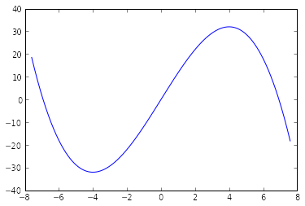

```python
x = np.arange(-7.6,7.6, .01)
y = 12 * x - x**3 / 4
plt.plot(x,y)
```

### Same thing for any function!

We have a bunch of parameters $\Theta$ we want to tune, and we have a cost function to minimise. The best thing to do would be to do the same thing as we did above and solve for $$\frac{\partial L(f(x),y)}{\partial w_i} = 0$$

But not always possible due to computational costs or formula has no closed form solution. What's the next best thing?

### Gradient Descent

$$w := w - \alpha \cdot \frac{\partial L}{\partial w}$$

## Chain rule

So what happens if you have some complicated cost function that looks something like $L(g(f(w,x)),y)$, and we need to adjust $w$?

$$ \frac{\partial z}{\partial y} = \frac{\partial z}{\partial w}\frac{\partial w}{\partial y}$$

If you remember the chain rule, it's not that hard to do something like this:

$$ \begin{align*} z &= f(w,x) \\ \hat{y} &= g(z) \\ \frac{\partial}{\partial w} L(\hat{y},y) &= \frac{\partial L(\hat{y},y)}{\partial \hat{y}} \frac{\partial \hat{y}}{\partial z} \frac{\partial z}{\partial \hat{w}} \end{align*} $$

Walau so much maths. What does this have to do with neural networks?

### Chain rule and backpropagation

$$L(f(w_3,f(w_2,f(w_1,x))),y)$$

[figure not shown]

### Chain rule as memoization

$$L(f(w_3,f(w_2,f(w_1,x))),y)$$

[figure not shown]

### Automatic differentiation

This doesn't stop at neural network architectures. This can be done for any differentiable function, and it is modular.

1. Write the expression
2. Implement the expression as a computation graph (DAG)
3. Go from the output back to the parameters and compute the expressions for the gradients
4. Toposort the whole thing to know sequence of dependencies

Many libraries that already do this:

- Python
  - Theano http://deeplearning.net/software/theano/ (library used primarily for neural networks research)
  - SymPy http://www.sympy.org/en/index.html (Computer algebra library)
- Julia
  - JuliaDiff http://www.juliadiff.org/ (probably more mathematically grounded)
- Haskell
  - ad https://hackage.haskell.org/package/ad (I don't know anything about this.)

## AI Winter (1966 - 1990s)

[figure not shown]

1. More complicated problem -> more steps of computation -> more layers
2. Backpropagation had problems with deep networks (More than 2 layers)
3. A lot of promise for neural networks, but too many problems.
4. A lot of promise for AI in general, too much funding to AI companies with shitty returns

## ReNNaissance (2007-ish)

Rebranding as *deep learning*

[figure not shown]

Layer-wise pretraining learns (using unlabelled data) what the data looks like in general.

## Edge detectors first and then...

[figure not shown]

## Recognising cats and faces (but who cares about faces)

[figure not shown]

## Explaining what pre-training is...

```python
# a video showing running the RBM through several iterations. "Daydreaming"...
YouTubeVideo('LzE1fF0_3q0')
```

[video not shown]

### Computer Vision: ConvNets

[figure not shown]

### Speech Recognition: DNN Acoustic Models

[figure not shown]

### Natural Language Processes: Word embeddings

[figure not shown]

## Sensationalism

[figure not shown]

> The Google brain assembled a dreamlike digital image of a cat by employing a hierarchy of memory locations to successively cull out general features after being exposed to millions of images. The scientists said, however, that it appeared they had developed a cybernetic cousin to what takes place in the brain’s visual cortex.

## Big companies buying up Big researchers

[figure not shown]

Four heavenly kings from left to right:

- Yann LeCun (Facebook)
- Geoffrey Hinton (Google)
- Yoshua Bengio (Untempted by the dark side.)
- Andrew Ng (Baidu)

## Buying up deep learning companies...

[figure not shown]

```python
# DeepMind sell koyok...
YouTubeVideo('CUhflgWvvoo')
```

[video not shown]

## During a backchannel interview...

> *You’ve had successful experiments, but how difficult is it to build those into a system that hundreds of millions of people will use?*

> It’s a multi-step process. You start with the research question and find that answer. Then we do **some major neuroscience** and then we look at it in machine learning and we implement a practical system that can play Atari really well and then that’s ready to scale. Here at Deep Mind about three quarters of the team is research but one quarter is applied. That team is the interface between the research that gets done here and the rest of Google’s products.

## Deep Neural Networks and Reinforcement Learning...

### Facebook M

[figure not shown]

## Fear, uncertainty and doubt

[figure not shown]

## Too much optimism

[figure not shown]

## All of this has happened before and will happen again.

[figure not shown]

(Battlestar Galactica reference.)

## End.

@ML_Hipster